# burnout_predictors

Eric Yan

7/31/2021

```r
# Making the 'Resource' and 'Designation' predictor as factor, somehow make it impossible to fullfill the LINR assumption.
library(faraway)
library(readr)
library(lmtest)
library(leaps)
library(knitr)
train = read_csv("train_cleaned.csv")
train$Gender = factor(train$Gender)
train$'Type' = factor(train$'Type')
train$'WFH' = factor(train$'WFH')
#train$Resource = factor(train$Resource)
#train$Designation = factor(train$Designation)
train  = train[-1]  # drop ID
train = na.exclude(train) # exclude NA to easier data manipulation
str(train)
```

```
## tibble [18,590 × 8] (S3: tbl_df/tbl/data.frame)
##  $ Gender     : Factor w/ 2 levels "Female","Male": 1 2 2 1 2 1 1 2 2 2 ...
##  $ Type       : Factor w/ 2 levels "Product","Service": 2 2 2 2 1 2 2 1 2 1 ...
##  $ WFH        : Factor w/ 2 levels "No","Yes": 1 2 2 1 2 1 2 2 2 2 ...
##  $ Designation: num [1:18590] 2 1 1 3 2 3 2 2 0 1 ...
##  $ Resource   : num [1:18590] 3 2 1 7 4 6 4 3 1 3 ...
##  $ Fatigue    : num [1:18590] 3.8 5 2.6 6.9 3.6 7.9 4.4 5.3 1.8 5.8 ...
##  $ Burn       : num [1:18590] 0.16 0.36 0.2 0.52 0.29 0.62 0.33 0.5 0.12 0.51 ...
##  $ Days       : num [1:18590] 92 31 58 160 35 364 61 290 233 231 ...
##  - attr(*, "na.action")= 'exclude' Named int [1:3036] 3 9 10 13 14 20 24 25 26 30 ...
##   ..- attr(*, "names")= chr [1:3036] "3" "9" "10" "13" ...
```

Diagnostics function to quickly check for LINE assumptions and model evaluation metrics, including adjusted R-square, LOOCV and BIC.  
BIC is choosen over AIC here because sample size is large.

```r
diagnostics = function(model, pcol = 'grey', lcol = 'dodgerblue', alpha = 0.05,
                       plotit = TRUE, testit = TRUE) {

  if (plotit) {
    par(mfrow = c(1, 2))
    plot(fitted(model), resid(model), xlab = 'Fitted', ylab = 'Residuals',
         col = pcol, pch = 20, cex = 2)
    abline(h = 0, col = lcol, lwd = 3, main = "Fitted vs Residuals")

    qqnorm(resid(model), col = pcol, pch = 20, cex = 1,
           main = "Normal Q-Q plot")
    qqline(resid(model), col = lcol, lwd = 3)
  }

  if (testit) {
    p_val = shapiro.test(resid(model))$p.value
    p_val_bp = as.numeric(bptest(model)$p.value)
    adj_r = summary(model)$adj.r.squared
    loocv = sqrt(mean((resid(model) / (1 - hatvalues(model))) ^ 2, na.rm = TRUE))
    n = length(resid(model))
    bic = extractAIC(model, k = log(n))[2]
    data.frame(shapiro.test = p_val, bptest = p_val_bp, adj.r.squared = adj_r, loocv = loocv, BIC = bic)
  }
}
```

```r
sel_size = 1000
set.seed(2021)
train = train[sample(nrow(train), sel_size),]
nrow(train)
```

```
## [1] 1000
```

Checking LINE assumptions, and find out that ‘Linear’, ‘Independent Variance’, ‘Variance Normality’ and ‘Equal Variance’ assumptions are violated.

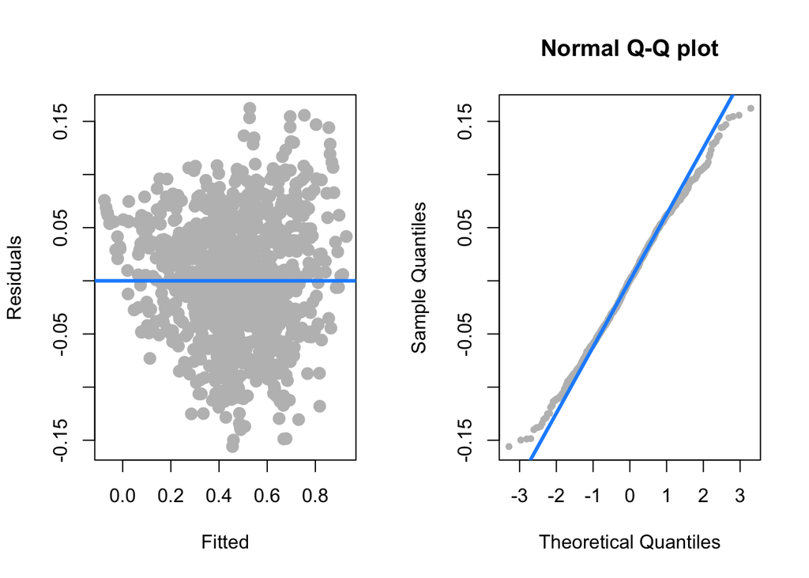

```
##   shapiro.test       bptest adj.r.squared      loocv       BIC
## 1   0.01680973 5.779568e-05     0.9177178 0.05797158 -5655.874
```

```r
mod_add = lm(Burn ~ ., data = train, na.action = na.exclude)
diagnostics(mod_add)
```

```r
summary(mod_add)$adj.r.squared
```

```
## [1] 0.9177178
```

```r
vif(mod_add)[vif(mod_add) > 5]
```

```
## Resource
## 6.578795
```

Check for corelation between ‘Burn’ and ‘Designation’ or ‘Resource’, with respect to the rest of the predictors.

```r
mod_co_De = lm(Burn ~ . - Designation, data = train)
mod_co = lm(Burn ~ . - Burn, data = train)
mod_co_Re = lm(Burn ~ . - Resource, data = train)
cor(resid(mod_co_De), resid(mod_co))
```

```
## [1] 0.9992586
```

```r
cor(resid(mod_co_Re), resid(mod_co))
```

```
## [1] 0.9272661
```

The above results shows that ‘Designation’ has higher colinearity issue with the rest predictors.

```r
mod_add_2 = lm(Burn ~ . - Designation, data = train, na.action = na.exclude)
vif(mod_add_2)
```

```
##  GenderMale TypeService      WFHYes    Resource     Fatigue        Days
##    1.031570    1.003113    1.124479    2.907748    2.894652    1.001162
```

```r
diagnostics(mod_add_2, plotit = FALSE)
```

```
##   shapiro.test       bptest adj.r.squared      loocv       BIC
## 1   0.01365506 3.743806e-05     0.9176786 0.05796589 -5661.298
```

```r
summary(mod_add_2)$coefficients
```

```
##                  Estimate   Std. Error     t value      Pr(>|t|)
## (Intercept) -9.033288e-02 0.0082008259 -11.0150960  1.056475e-26
## GenderMale   7.313219e-03 0.0037108168   1.9707841  4.902599e-02
## TypeService  2.503493e-03 0.0038284731   0.6539143  5.133184e-01
## WFHYes      -8.463978e-03 0.0038784283  -2.1823216  2.931954e-02
## Resource     2.636823e-02 0.0014846192  17.7609411  1.683148e-61
## Fatigue      7.426268e-02 0.0016102685  46.1181968 4.281844e-249
## Days        -5.466708e-06 0.0000171279  -0.3191697  7.496649e-01
```

Check possible relation between three factor predictor and response ‘Burn’ by boxplot. The finding matches with the p_values of the basic model `mod_add_2`, where `Type` has no significant linear relationship with the response.

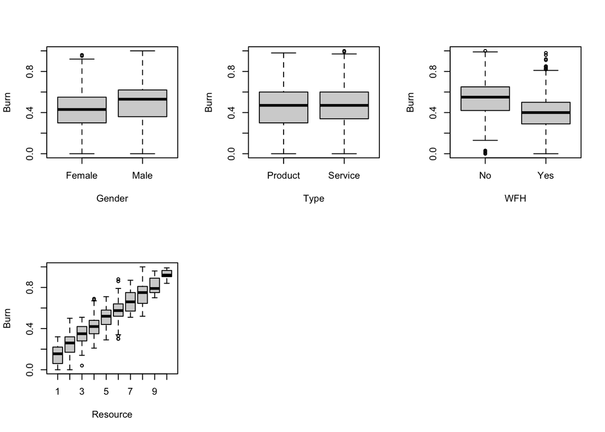

```r
par(mfrow = c(2, 3))
boxplot(Burn ~ Gender, data = train)
boxplot(Burn ~ Type, data = train)
boxplot(Burn ~ WFH, data = train)
boxplot(Burn ~ Resource, data = train)
```

Check for relationship of numeric predictors by scatterplots.

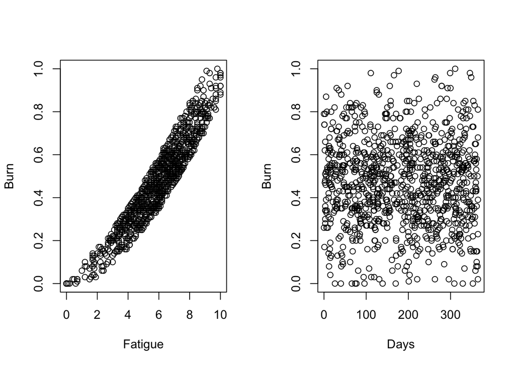

```r
par(mfrow = c(1, 2))
plot(Burn ~ Fatigue, data = train)
plot(Burn ~ Days, data = train)
```

From the plot, it’s obvious that ‘Days’ and the response has no clear relationship.  
‘Fatigue’ predicotr has a slightly curve relationship with ‘Burn’. By applying different power to the predictor, the following plots are obtained. It shows the power of `1.4` is the sweet spot and make the relationship more linear.

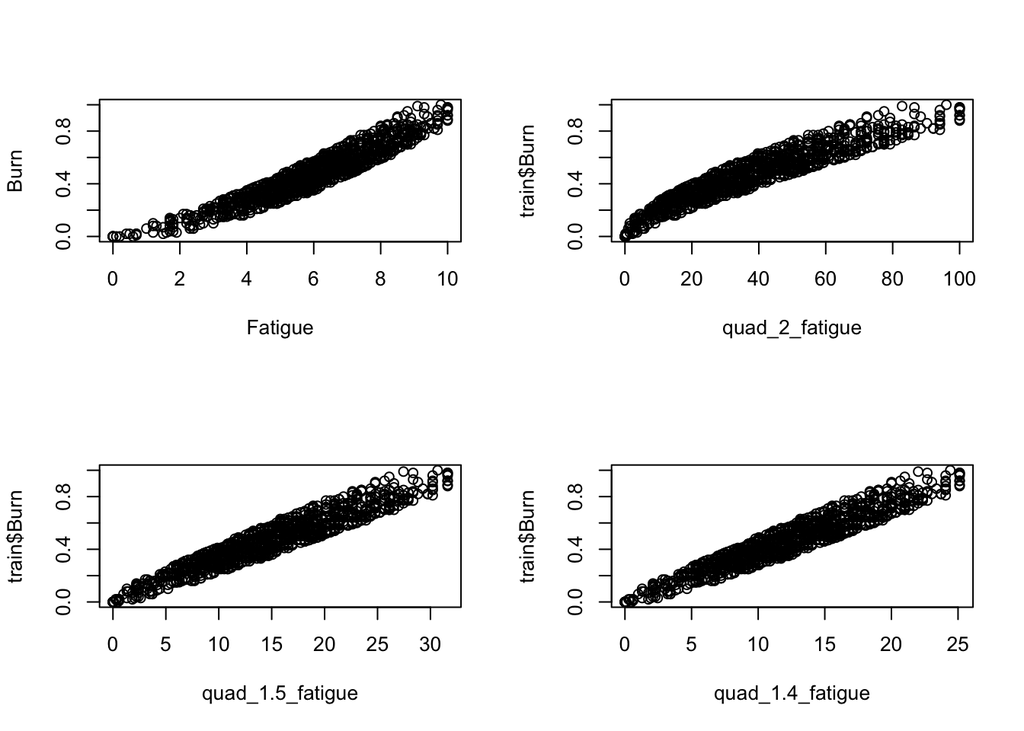

```r
par(mfrow = c(2, 2))
plot(Burn ~ Fatigue, data = train)
quad_2_fatigue = train$Fatigue ^ 2
plot(train$Burn ~ quad_2_fatigue)
quad_1.5_fatigue = train$Fatigue ^ 1.5
plot(train$Burn ~ quad_1.5_fatigue)
quad_1.4_fatigue = train$Fatigue ^ 1.4
plot(train$Burn ~ quad_1.4_fatigue)
```

```r
var(train$Fatigue[train$Fatigue > mean(train$Fatigue)])
```

```
## [1] 1.039997
```

```r
var(train$Fatigue < mean(train$Fatigue))
```

```
## [1] 0.2478468
```

Based on the above observation, I’m taking out ‘Type’ and ‘Days’ away from the model. The anova test also confirms the null hypothesis $H_0: \beta_{Type} = \beta_{Days} = 0$.

```r
mod_add_3 = lm(Burn ~ Gender + WFH + Resource + Fatigue, data = train, na.action = na.exclude)
diagnostics(mod_add_3, plotit = FALSE)
```

```
##   shapiro.test       bptest adj.r.squared      loocv       BIC
## 1   0.01081688 1.715786e-05     0.9177998 0.05786238 -5674.575
```

```r
anova(mod_add_3, mod_add_2)
```

```
## Analysis of Variance Table
##
## Model 1: Burn ~ Gender + WFH + Resource + Fatigue
## Model 2: Burn ~ (Gender + Type + WFH + Designation + Resource + Fatigue +
##     Days) - Designation
##   Res.Df    RSS Df Sum of Sq      F Pr(>F)
## 1    995 3.3156
## 2    993 3.3138  2 0.0017855 0.2675 0.7653
```

```r
mod_pow_1 = lm(Burn ~ Gender + WFH + Resource + Fatigue + I(Fatigue ^ 1.4), data = train)
diagnostics(mod_pow_1, plotit = FALSE)
```

```
##   shapiro.test       bptest adj.r.squared      loocv       BIC
## 1  0.004286065 6.519916e-08     0.9212269 0.05663654 -5711.258
```

```r
anova(mod_add_3, mod_pow_1)
```

```
## Analysis of Variance Table
##
## Model 1: Burn ~ Gender + WFH + Resource + Fatigue
## Model 2: Burn ~ Gender + WFH + Resource + Fatigue + I(Fatigue^1.4)
##   Res.Df    RSS Df Sum of Sq      F    Pr(>F)
## 1    995 3.3156
## 2    994 3.1742  1   0.14142 44.287 4.678e-11 ***
## ---
## Signif. codes:  0 '***' 0.001 '**' 0.01 '*' 0.05 '.' 0.1 ' ' 1
```

So far, there’re two preferred models. The additive model with ‘Gender’, ‘WFH’, ‘Resource’ and ‘Fatigue’, and the model with an extra term of ‘Fatigue’ to the power of `1.4`.  
Neither model passes both shapiro test or bptest.  
Let’s check for influential data.

```r
sum(cooks.distance(mod_add_3) > 4 / length(cooks.distance(mod_add_3)))
```

```
## [1] 38
```

```r
sum(cooks.distance(mod_pow_1) > 4 / length(cooks.distance(mod_pow_1)))
```

```
## [1] 30
```

Excluding the influential points and refit the power model.  
Influential points in both models are excluded, so that models could be refit on the same data and conduct anova test later.

```r
pow_mod_cd = cooks.distance(mod_pow_1) < 4 / length(cooks.distance(mod_pow_1))
add_mod_cd = cooks.distance(mod_add_3) < 4 / length(cooks.distance(mod_add_3))
mod_pow_2 = lm(Burn ~ Gender + WFH + Resource + Fatigue + I(Fatigue ^ 1.4),
               data = train,
               subset = pow_mod_cd & add_mod_cd)
diagnostics(mod_pow_2, plotit = FALSE)
```

```
##   shapiro.test       bptest adj.r.squared      loocv       BIC
## 1 1.135835e-05 3.363764e-05     0.9288157 0.05210493 -5635.576
```

```r
mod_add_4 = lm(Burn ~ Gender + WFH + Resource + Fatigue,
               data = train,
               subset = pow_mod_cd & add_mod_cd)
diagnostics(mod_add_4, plotit = FALSE)
```

```
##   shapiro.test     bptest adj.r.squared      loocv       BIC
## 1  1.40814e-05 0.07816426     0.9266307 0.05290591 -5612.442
```

```r
model_list = list(mod_add, mod_add_2, mod_add_3, mod_add_4, mod_pow_1, mod_pow_2)
metrics_table = matrix(ncol = 5, nrow = 0)
formulas = rep('', 5)
for (i in 1:length(model_list)) {
  formulas[i] = toString(model_list[[i]]$call$formula)
  temp_row = unlist(diagnostics(model_list[[i]], plotit = FALSE))
  metrics_table = rbind(metrics_table, temp_row)
}
colnames(metrics_table) = c('Shapiro Test', 'BP Test', 'Adj R.sq', 'LOOCV', 'BIC')
rownames(metrics_table) = formulas
kable(metrics_table)
```

|  | Shapiro Test | BP Test | Adj R.sq | LOOCV | BIC |
| --- | --- | --- | --- | --- | --- |
| ~, Burn, . | 0.0168097 | 0.0000578 | 0.9177178 | 0.0579716 | -5655.874 |
| ~, Burn, . - Designation | 0.0136551 | 0.0000374 | 0.9176786 | 0.0579659 | -5661.298 |
| ~, Burn, Gender + WFH + Resource + Fatigue | 0.0108169 | 0.0000172 | 0.9177998 | 0.0578624 | -5674.575 |
| ~, Burn, Gender + WFH + Resource + Fatigue | 0.0000141 | 0.0781643 | 0.9266307 | 0.0529059 | -5612.442 |
| ~, Burn, Gender + WFH + Resource + Fatigue + I(Fatigue^1.4) | 0.0042861 | 0.0000001 | 0.9212269 | 0.0566365 | -5711.258 |
| ~, Burn, Gender + WFH + Resource + Fatigue + I(Fatigue^1.4) | 0.0000114 | 0.0000336 | 0.9288157 | 0.0521049 | -5635.576 |

Next, let’s try to find another preferred model by applying the backward `step` function to involve interactions and quadratic relationship.

```r
mod_all = lm(Burn ~ . ^ 2, data = train)
mod_bic_back = step(mod_all, trace = 0, k = log(length(resid(mod_all))))
mod_bic_back$call$formula
```

```
## Burn ~ Resource + Fatigue + Resource:Fatigue
```

```r
rowname = toString(mod_bic_back$call$formula)
formulas = c(formulas, rowname)
metrics_table = rbind(metrics_table, unlist(diagnostics(mod_bic_back, plotit = FALSE)))
rownames(metrics_table) = formulas
```

```r
bic_mod_cd = cooks.distance(mod_bic_back) < 4 / length(cooks.distance(mod_bic_back))
mod_bic_back_2 = lm(Burn ~ Resource + Fatigue + Resource:Fatigue, data = train, subset = bic_mod_cd)
rowname = toString(mod_bic_back_2$call$formula)
formulas = c(formulas, rowname)
metrics_table = rbind(metrics_table, unlist(diagnostics(mod_bic_back_2, plotit = FALSE)))
rownames(metrics_table) = formulas
kable(metrics_table)
```

|  | Shapiro Test | BP Test | Adj R.sq | LOOCV | BIC |
| --- | --- | --- | --- | --- | --- |
| ~, Burn, . | 0.0168097 | 0.0000578 | 0.9177178 | 0.0579716 | -5655.874 |
| ~, Burn, . - Designation | 0.0136551 | 0.0000374 | 0.9176786 | 0.0579659 | -5661.298 |
| ~, Burn, Gender + WFH + Resource + Fatigue | 0.0108169 | 0.0000172 | 0.9177998 | 0.0578624 | -5674.575 |
| ~, Burn, Gender + WFH + Resource + Fatigue | 0.0000141 | 0.0781643 | 0.9266307 | 0.0529059 | -5612.442 |
| ~, Burn, Gender + WFH + Resource + Fatigue + I(Fatigue^1.4) | 0.0042861 | 0.0000001 | 0.9212269 | 0.0566365 | -5711.258 |
| ~, Burn, Gender + WFH + Resource + Fatigue + I(Fatigue^1.4) | 0.0000114 | 0.0000336 | 0.9288157 | 0.0521049 | -5635.576 |
| ~, Burn, Resource + Fatigue + Resource:Fatigue | 0.0018165 | 0.0000002 | 0.9212792 | 0.0565743 | -5723.728 |
| ~, Burn, Resource + Fatigue + Resource:Fatigue | 0.0000447 | 0.0000708 | 0.9250732 | 0.0534994 | -5647.535 |